# How fateful?

Channon Perry

2022-08-25

# Introduction

When I met my boyfriend I often felt bewildered that despite living in the same city for five years and attending the same university that it took a dating app to introduce us. Thanks to Google’s location history quietly ticking away collecting GPS data in the background I thought that I could potentially find a real answer to just how fatefully our paths crisscrossed before we met.

# Sourcing the data

You can request and download all of your recorded location history through the Google Maps desktop website. This data comes in a zipped folder full of JSON files. My partner kindly agreed to download his data himself, and then sent it to me.

## Extract

```r
#Names of two people
x <- "Chan"
y <- "Dan"

#Records file addresses (reference the Records.json file)

data_x <-
  "~/Crossing paths/TakeoutChannon/Location History/Records.json"
data_y <-
  "~/Crossing paths/TakeoutDandre/Location History/Records.json"

#Function from the fromJSON library to extract the JSON files into R list objects

extract_maps_data <- function(fileName, saveAs) {
  rd <- fromJSON(file = fileName)

  records_data <- unlist(rd, recursive = FALSE)

  save(records_data, file = saveAs)

  records_data

}

#Running the extract function on the data if it hasn't been run before, otherwise loading it in

if (file.exists("extracted_data_x.RData")) {
  records_data_x <- get(load("extracted_data_x.RData"))
} else {
  records_data_x <- extract_maps_data(fileName = data_x,
                                      saveAs = "extracted_data_x.RData")
}

if (file.exists("extracted_data_y.RData")) {
  records_data_y <- get(load("extracted_data_y.RData"))
} else {
  records_data_y <- extract_maps_data(fileName = data_y,
                                      saveAs = "extracted_data_y.RData")
}
```

## Transform

### Set parameters

Before we jump right into transforming and cleaning the data it’s necessary to set some boundaries around time frames and accuracy so that we don’t spend time processing unnecessary records.

#### Distance margin

This table displays how the distance accuracy measures relate to each other.

| accuracy.level | 1 | 2 | 3 | 4 |
| --- | --- | --- | --- | --- |
| decimal places | 3 | 4 | 5 | 6 |
| accuracy (m) | 111 | 11.1 | 1.11 | 0.111 |
| coordinates | +/- 00.000 | +/- 00.0000 | +/- 00.00000 | +/- 00.000000 |

Our data has two types of accuracy indicators. The GPS coordinates have differing number of decimal places depending on the specificity of the location. There is a also a reported accuracy measurement based on the strength of the signal of the GPS at the time and is reported in meters.

These accuracy measures define the margin of error in distance for any of the conclusions that we draw. That is, when we potentially conclude that him and I did cross paths, did we come into tens, or hundreds, or thousands of meters from each other? I initially chose 11.1m, related to coordinates with 4 decimal places (+/- 00.0000), because I thought that even in dense urban areas the length of a telephone pole had a tantalizingly high probability of being within sight. However, the quality of the data (see below) limited the records too much, forcing me to use a distance accuracy of 111m instead.

```r
#Distance margin
accuracy_level <- 1
```

#### Time margins

We also need to define the time boundaries of the two data sets. The first date is the earliest possible date that we had any real probability of having come into contact. This could also be set to the minimum date in either of the two sets if there’s no clear probable contact time like moving to the same city.

```
## [1] "Chan 's earliest record is 2014-10-11"
```

```
## [1] "Dan 's earliest record is 2015-01-13"
```

```
## [1] "Use 2015-01-13 or first_intersect_date to start at earliest intersecting dates."
```

```r
start_looking_from <- as.POSIXct(first_intersect_date) #Start date to start analysing data from
```

There is also an end date to the time set. That is the date and time that we’re definitely certain that our GPS coordinates would have matched up for the first time.

```r
best_day <- as.POSIXct("2020/08/08 1:00:00") #The confirmed first meeting <3
```

Similarly to distance margins, it’s also helpful to set time intervals to group coordinates into. This is because when considering a scale of meters people just don’t tend to move fast enough across the surface of the earth on a day-to-day basis for it to be necessary to record our location many times a second, however, the data is stored down to millisecond time stamps.

I chose 10 minutes because it was also a margin I was happy with having on either side of my insights, i.e. we may have sat on the same bench 10 minutes apart.

```r
#Time margins
time_accuracy <- "10 mins" #The granularity of time buckets. Use ?round_date to see time categories available.
```

The tree-style lists I’ve converted the JSON files from are still in an unrefined state. Currently, each data set is made up of hundreds of thousands of observations, each of which is in a listed format with the below structure:

```
## List of 7
##  $ latitudeE7 : num -2.59e+08
##  $ longitudeE7: num 2.92e+08
##  $ accuracy   : num 2459
##  $ activity   :List of 2
##  $ source     : chr "CELL"
##  $ deviceTag  : num 1.44e+09
##  $ timestamp  : chr "2014-10-11T14:39:52.645Z"
```

By the time we’re complete transforming the data we would like to have two data frames, one for each person, with the following structure:

| index | timestamp | latitude | longitude | accuracy | person | coordinates | source |
| --- | --- | --- | --- | --- | --- | --- | --- |
| 1:nrows | POSIXct time | dd coords | dd coords | m radius | name | lat, long | signal source |

To do that we’ll run the following function on both data sets:

```r
transform_maps_data <- function(x, person, time_accuracy, distance_accuracy){

  # Extracting the variables that we're interested in and dropping all the information related to whether Google thinks we were in a vehicle or sitting still.

  timestamp <- lapply(x, pluck, "timestamp") %>% unlist() %>% data.frame()
  latitude <- lapply(x, pluck, "latitudeE7") %>% unlist() %>% data.frame()
  longitude <- lapply(x, pluck, "longitudeE7") %>% unlist() %>% data.frame()
  accuracy <- lapply(x, pluck, "accuracy") %>% unlist() %>% data.frame()
  source <- lapply(x, pluck, "source") %>% unlist() %>% data.frame()

  # Setting an index
  index <- 1:nrow(timestamp)

  # Combining each of the variables into a data frame as columns with clear names.

  records_df <- cbind(timestamp, latitude, longitude, accuracy, source)
  rownames(records_df) <- index
  colnames(records_df) <- c("timestamp", "latitude", "longitude", "accuracy", "source")

  # Adjusting the formatting and adding some key columns.
  output <- records_df %>%

  # Formatting the time stamps so that they are POSIXct objects in the system timezone and rounding them off into the given accuracy limits
    mutate(timestamp_utc = as.POSIXct(timestamp, format = "%Y-%m-%dT%H:%M:%S", tz = "UTC")) %>%
    mutate(timestamp = with_tz(timestamp_utc, tzone = Sys.timezone())) %>%
    select(-timestamp_utc) %>%
    mutate(timestamp = round_date(timestamp, unit = time_accuracy)) %>%

  # Adding a column with the name of the individual who the records belong to
    mutate(person = person) %>%

  # Latitude and longitude are in a suitable format to allow for quick copy and pasting into Google Maps, and are filtered within the distance.accuracy number of decimal points

    mutate(latitude = round((latitude/10000000), distance_accuracy)) %>%
    mutate(longitude = round((longitude/10000000), distance_accuracy)) %>%

  # Adding a column for combined coordinates
    mutate(coordinates = paste(latitude, longitude, sep = ", ")) %>%

  # Filtering our any records outside of reported accuracy
    filter(accuracy <= google_reported_accuracy) %>%
    filter(accuracy >= 0) %>%

  # Filtering our any records before or after start and end dates
    filter(timestamp >= start_looking_from) %>%
    filter(timestamp <= best_day) %>%

  # Removing unknown sources for integrity
    filter(source != "UNKNOWN") %>%

  # Removing duplicates
    unique()

}

#Running the function on the two data sets or otherwise loading data we've already saved before.

if(file.exists("X_Google_Maps_history.RData")) {
  load("X_Google_Maps_history.RData")
} else{
  x_records <-
    transform_maps_data(
      records_data_x,
      person = x,
      time_accuracy = time_accuracy,
      distance_accuracy = distance_accuracy
    )
}

if(file.exists("Y_Google_Maps_history.RData")) {
  load("Y_Google_Maps_history.RData")
} else{
  y_records <-
    transform_maps_data(
      records_data_y,
      person = y,
      time_accuracy = time_accuracy,
      distance_accuracy = distance_accuracy
    )
}
```

At the end of our transform step we have two data frames with the following structure:

```
##              timestamp latitude longitude accuracy source person    coordinates
## 1  2015-01-13 02:00:00   -25.89    29.252       12   CELL   Chan -25.89, 29.252
## 5  2015-01-13 02:10:00   -25.89    29.252       12   CELL   Chan -25.89, 29.252
## 8  2015-01-13 02:10:00   -25.89    29.252       27   CELL   Chan -25.89, 29.252
## 10 2015-01-13 02:20:00   -25.89    29.252       27   CELL   Chan -25.89, 29.252
## 14 2015-01-13 02:30:00   -25.89    29.252       27   CELL   Chan -25.89, 29.252
## 18 2015-01-13 02:40:00   -25.89    29.252       27   CELL   Chan -25.89, 29.252
```

## Load

Saving the files.

```r
save(x_records, file = "X_Google_Maps_history.RData")
save(y_records, file = "Y_Google_Maps_history.RData")
```

# Analysis

## Combining the records

Working with one dataset is easier than working with two in this case so we’ll create one long-version of all the records for analysis.

```
## # A tibble: 418,929 × 7
## # Groups:   timestamp, coordinates, person [408,904]
##    timestamp           latitude longitude source person coordinates max_accuracy
##    <dttm>                 <dbl>     <dbl> <chr>  <chr>  <chr>              <dbl>
##  1 2015-01-13 02:00:00    -25.9      29.3 CELL   Chan   -25.89, 29…           12
##  2 2015-01-13 02:10:00    -25.9      29.3 CELL   Chan   -25.89, 29…           12
##  3 2015-01-13 02:20:00    -25.9      29.3 CELL   Chan   -25.89, 29…           27
##  4 2015-01-13 02:30:00    -25.9      29.3 CELL   Chan   -25.89, 29…           27
##  5 2015-01-13 02:40:00    -25.9      29.3 CELL   Chan   -25.89, 29…           27
##  6 2015-01-13 02:50:00    -25.9      29.3 CELL   Chan   -25.89, 29…           27
##  7 2015-01-13 03:00:00    -25.9      29.3 CELL   Chan   -25.89, 29…           27
##  8 2015-01-13 03:10:00    -25.9      29.3 CELL   Chan   -25.89, 29…           25
##  9 2015-01-13 03:20:00    -25.9      29.3 CELL   Chan   -25.89, 29…           25
## 10 2015-01-13 03:30:00    -25.9      29.3 CELL   Chan   -25.89, 29…           25
## # … with 418,919 more rows
```

```
## # A tibble: 5 × 7
## # Groups:   timestamp, coordinates, person [5]
##   timestamp           latitude longitude source person coordinates  max_accuracy
##   <dttm>                 <dbl>     <dbl> <chr>  <chr>  <chr>               <dbl>
## 1 2018-10-20 16:00:00    -25.3      31.0 WIFI   Dan    -25.344, 31…           17
## 2 2018-10-20 16:10:00    -25.3      31.0 WIFI   Dan    -25.344, 31…           17
## 3 2015-12-29 09:50:00    -25.4      29.4 WIFI   Chan   -25.395, 29…           96
## 4 2015-12-29 10:00:00    -25.4      29.4 WIFI   Chan   -25.395, 29…           51
## 5 2015-12-29 10:20:00    -25.4      29.4 WIFI   Chan   -25.395, 29…           58
```

## Data quality and completeness

### Data completeness

Gaps in records could be due to a lack of mobile data (which is notably expensive in South Africa) or our cellphones being turned off while traveling. Further, there may be gaps when privacy settings disallowed the collection of location history.

These variables means that no matter the result, there will still be some uncertainty during the un-recorded periods where we may have crossed pathways but no evidence exists.

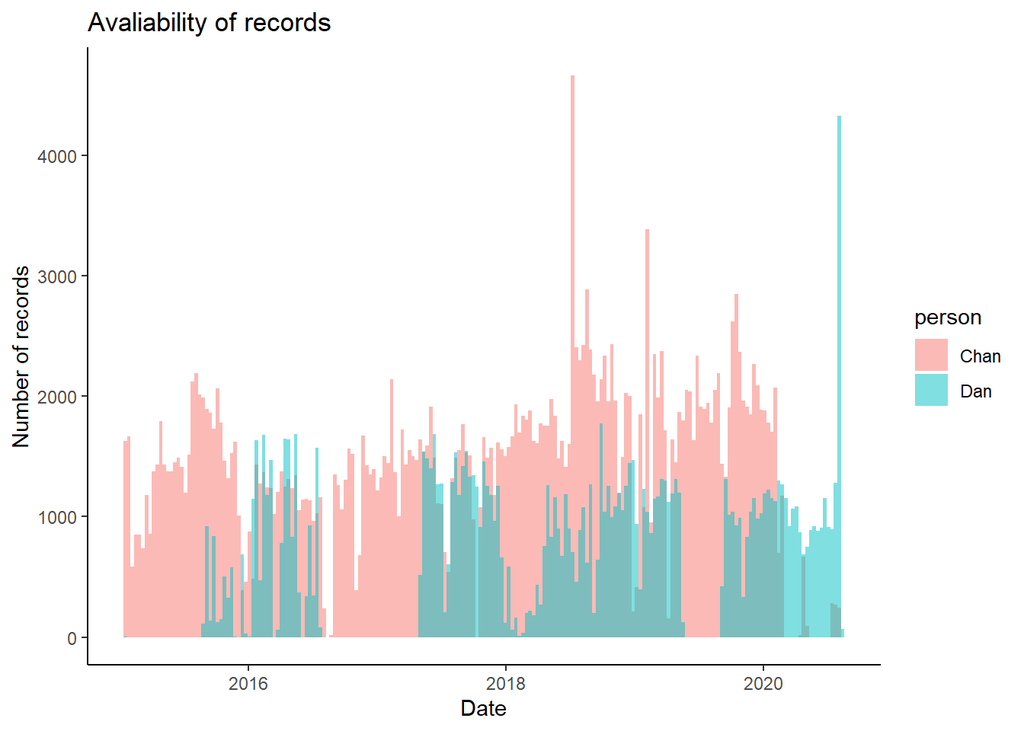

The timeline under review, showing the avaliability of records per person. Only time periods with records for both people will contain potential matches

### Source composition of records

Analysing the source of the records show that the majority of the collected records came from instances where the cellphone was connected to WiFi.

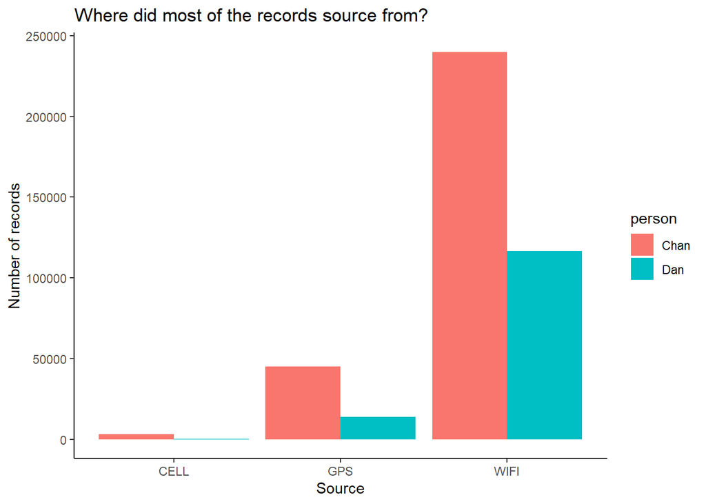

The number of records by person and by source.

We can understand this better by looking to the aggregate number of unique records per unique locations by source. WiFi had the greatest number of records per location because everything in range of the WiFi router was centralised to the router’s location when cellphones connected to WiFi. The same is true for cell towers, however at a lesser rate. GPS records were the most likely to be detailed.

Unique coordinates vs unique records per source

| source | unique_locations | unique_records | records_per_location |
| --- | --- | --- | --- |
| CELL | 256 | 3239 | 12.7 |
| GPS | 16303 | 58865 | 3.6 |
| WIFI | 6747 | 356825 | 52.9 |

### Source accuracy

Finally, it’s important to consider the differences in accuracy of the different sources. Along with being the most likely to record coordinates away from centralised WiFi routers or cell towers, GPS records are also on average the most accurate.

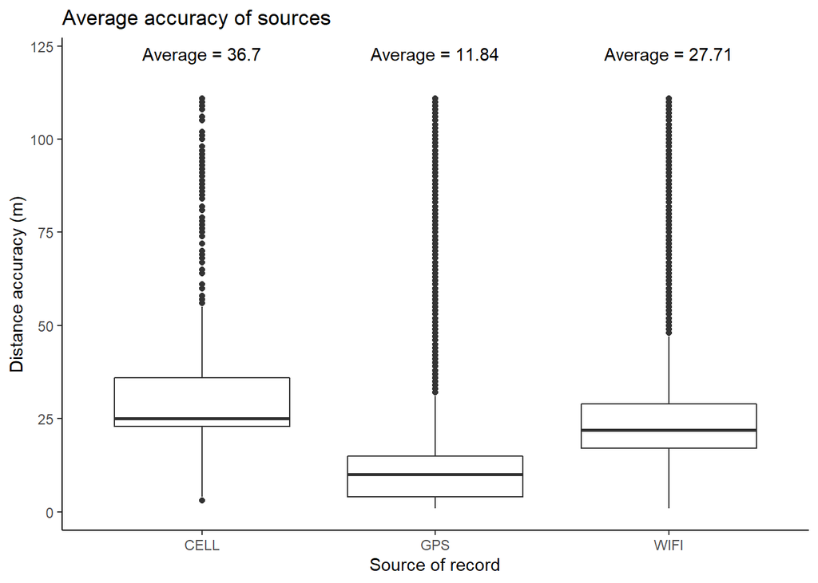

Boxplot showing accuracy statistics by record source. Remember that the minimum accuracy is set above, so the graph only considers records within the stated parameters.

## Places we’ve both frequently visited

This is an initial view of some of the most common places we both visited.

#### Visualizing all the places we had both been

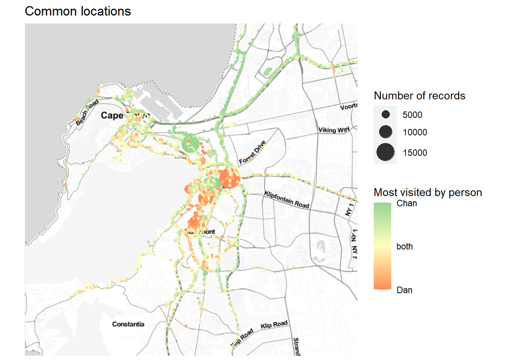

```r
# Get Map data from Google API

# Note: you'll need to get a key on the Google Maps platform to access the API.

# Go to https://mapsplatform.google.com/ -> get started -> credentials -> API keys
# Find Maps API Key and SHOW KEY, then copy and paste your API key below:
# register_google(key = "[your key]", write = TRUE)

#Set a colour palette
my_palette <- colorRampPalette(brewer.pal(3, "Spectral"))

#plot the map, scaling by number of records, and colouring by who visited most frequently

map_most_common_places <- get_map(
  location = c(
    lon = median(both_places$longitude),
    lat = median(both_places$latitude)
  ),
  zoom = 12,
  scale = "auto",
  maptype = "toner-lite"
)

ggmap(map_most_common_places) +
  geom_point(
    aes(
      x = longitude,
      y = latitude,
      size = both_records,
      colour = dif_per
    ),
    data = both_places,
    alpha = 0.8
  ) +
  scale_radius(range = c(1, 10),
               name = "Number of records") +
  scale_colour_gradientn(
    colours = my_palette(3),
    name = "Most visited by person",
    breaks = c(min(both_places$dif_per), 0, max(both_places$dif_per)),
    labels = c(y, "both", x)
  ) +
  theme(
    text = element_text(family = "sans"),
    axis.title = element_blank(),
    axis.text = element_blank(),
    axis.ticks = element_blank(),
    panel.grid = element_blank()
  ) +
  ggtitle(label = "Common locations")
```

There were 2729 coordinates we were both recorded in at some point during the five year time frame. It’s clear that most of the common locations are the main roads in and around the city. However, interestingly my partner had been within 111m of both my office and my apartment.